# 가장 많은 인구가 모여있는 서울

## 지하철 일일 이용객 분석으로 문제점과 해결 방안 알아보기

## 데이터 분석

### - 데이터 선정:

#### 1. 공공 데이터 포털

##### - 지하철 일일 이용객

##### - 현재 23개 노선으로 구성

#### 2. 크롬

##### - 네이버 기사(지하철 이용에 대한 기사및 정보)

##### - 지하철 정보 및 시간대 조사

```python
import pandas as pd
import matplotlib.pyplot as plt
import matplotlib as mpl
import numpy as np
mpl.rcParams['font.family'] = 'NanumGothic'
plt.rcParams['axes.unicode_minus'] = False
import matplotlib.font_manager as fm
font_files = fm.findSystemFonts(fontpaths=['C:/Users/moon/AppData/Local/Microsoft/Windows/Fonts'])
for fpath in font_files:
    fm.fontManager.addfont(fpath)
import os
os.chdir('C:\Python\Syntex\따로 공부\팀프로젝트(지하철)\데이터 정보')
```

# 문제점 파악

```python
#%% 문제점 파악
df = pd.read_csv('기사제목.csv')
print(df)
```

```
                                                기사제목
0               [단독]“서울 지하철 파업해도 퇴근시간 운행률 80% 유지할 것”
1      [이슈플러스] 광주신세계~더현대 잇는 지하철? “교통난 대비” vs “혈세 낭비”
2                      지하철성범죄, 구체적인 행위에 따라 무거운 혐의 인정
3   파업 때 지하철 ‘운행률’ 높이고, 버스는 ‘필수공익사업’으로?[어떻게 생각하십니까?]
4          [단독]서울 지하철 파업해도 출퇴근시간 운행률 80% 이상 유지 방안 추진
..                                               ...
65           서울 시내버스 노조 28일 총파업 가결…지하철 하루 202회 추가 운행
66                  17일 서울마라톤대회…"광화문에서 잠실까지 교통혼잡 예상"
67               사람들 서서 가는데…퇴근길 지하철, '캐리어'로 좌석 막은 승객
68            하루에 두번이나… 잇단 열차 고장으로 지하철 1호선 운행 지연(상보)
69              '서울 시내버스 파업으로 승강장이 혼잡하오니 주의하시기 바랍니다'

[70 rows x 1 columns]
```

# 지역별 인구수

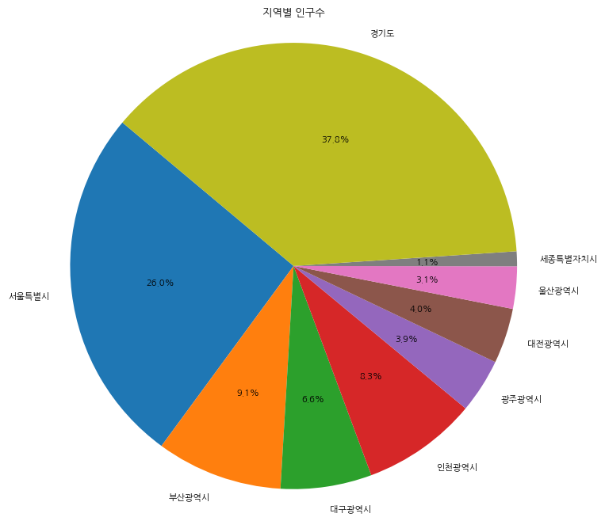

```python
population = pd.read_excel('24년_지역별_인구수.xlsx')
Population_near_Seoul = population.iloc[1] + population.iloc[9] # 서울과 근교 경기도의 합
Percentage_of_population_near_Seoul = np.array(Population_near_Seoul.iloc[1]*100/population.iloc[0,1],dtype=np.float16) # 전체 인구수에 차지하는 서울근교에 비율
b = population.iloc[1:10]
a = population.iloc[[0,1,9]]
plt.figure(figsize=(8, 8))
plt.pie(b['인구수'], labels=b['행정구역(시군구)별'], autopct='%1.1f%%', startangle=140)
plt.title('지역별 인구수')
plt.axis('equal')
plt.show()
```

### 수도권 인구수 대부분이 서울과 경기도에 몰려있는걸 알수있습니다.

#### 그래서 저희는 서울시 지하철 호선별 역별 시간대별 승하차 데이터를 가져와서 상위 15개 역만

#### 그래프로 만들어보았습니다.

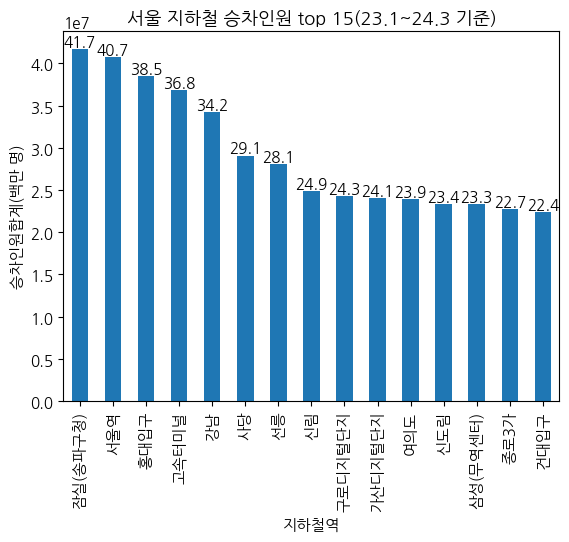

```python
for i in subway_people.index:
    if int(subway_people.loc[i, '사용월']) == 202301:
        break
subway_people = subway_people.loc[:9246, :]

# 승차인원만 추출
in_df = subway_people.columns.tolist()[:3]
for a in subway_people.columns.tolist():
    if a.find('승차') != -1:
        in_df.append(a)
in_df1 = subway_people[in_df]
plt.rcParams['font.size'] = 11

# # 승차인원만 합계 구하기
# in_df1['승차합계'] = in_df1[[column for column in in_df1.columns if '승차인원' in column]].sum(axis=1)
in_df1.loc[:, '승차합계'] = in_df1[[column for column in in_df1.columns if '승차' in column]].sum(axis=1)

# 상위 15개 지하철역 추출
top_15_stations = in_df1.groupby('지하철역')['승차합계'].sum().nlargest(15)

# 막대 그래프 그리기
ax = top_15_stations.plot(kind='bar')

# 각 막대 위에 값 표시 (단위: 백만 명)
for i in ax.patches:
    ax.text(i.get_x() + i.get_width() / 2, i.get_height(), f"{i.get_height() / 1000000:.1f}", ha='center', va='bottom')
# 축 레이블 추가
plt.ylabel('승차인원합계(백만 명)')

# 제목 추가
plt.title('서울 지하철 승차인원 top 15(23.1~24.3 기준)')

# 그래프 표시
plt.show()
```

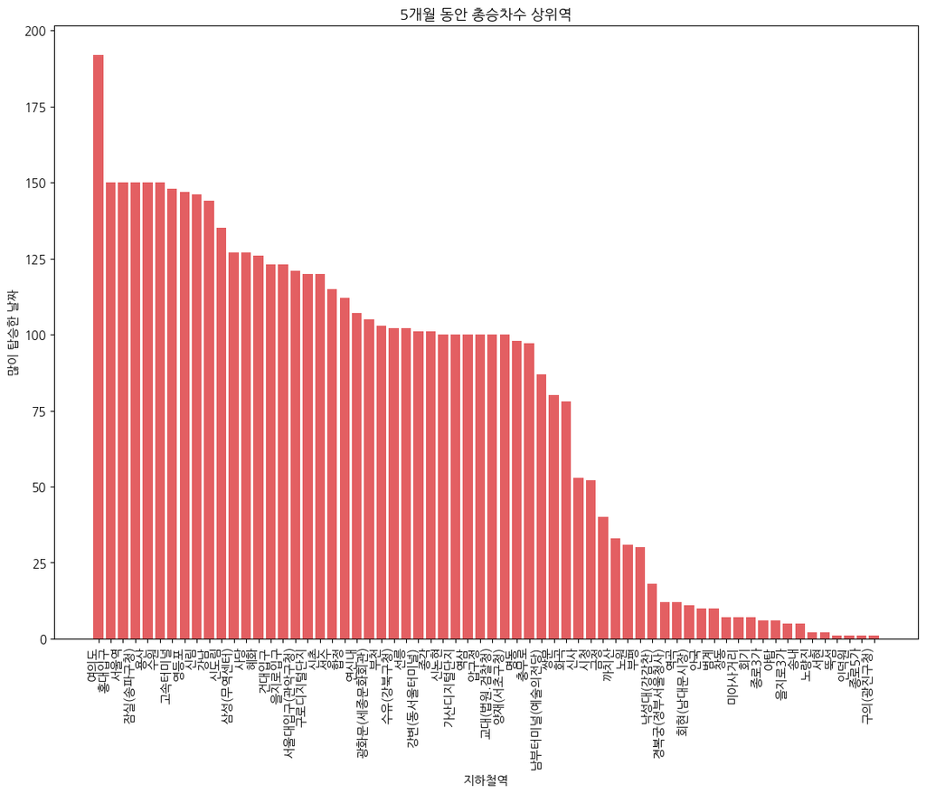

```python
# 서울과 경기권에 인구 비율은 전체에 44.88% 그 많은 인구가 이용하는 지하철에 일일 이용객을 알아보자

mon_2310 = pd.read_csv('CARD_SUBWAY_MONTH_202310.csv', encoding='cp949')
mon_2311 = pd.read_csv('CARD_SUBWAY_MONTH_202311.csv', encoding='cp949')
mon_2312 = pd.read_csv('CARD_SUBWAY_MONTH_202312.csv', encoding='cp949')
mon_2401 = pd.read_csv('CARD_SUBWAY_MONTH_202401.csv', encoding='cp949')
mon_2402 = pd.read_csv('CARD_SUBWAY_MONTH_202402.csv', encoding='cp949')
# 승차총승객수로 상위 1000개 역 분리
mon10 = mon_2310.sort_values(by="승차총승객수", ascending=False).head(1000)
mon11 = mon_2311.sort_values(by="승차총승객수", ascending=False).head(1000)
mon12 = mon_2312.sort_values(by="승차총승객수", ascending=False).head(1000)
mon01 = mon_2401.sort_values(by="승차총승객수", ascending=False).head(1000)
mon02 = mon_2402.sort_values(by="승차총승객수", ascending=False).head(1000)
# 1달간 승차총승객수에서 역명이 중복되는 값확인해서 상위 100개 추출
# 평균적으로 사람들이 많이 타는 역
mon_10 = mon10['역명'].value_counts().head(100)
mon_11 = mon11['역명'].value_counts().head(100)
mon_12 = mon12['역명'].value_counts().head(100)
mon_01 = mon01['역명'].value_counts().head(100)
mon_02 = mon02['역명'].value_counts().head(100)
# 5개월중에 상위 역 추출
df = pd.concat([mon_10, mon_11, mon_12, mon_01, mon_02],join='inner')
c = df.reset_index(drop=False)
d = c.groupby('역명').sum()
# 상위
result = d.sort_values(by='count', ascending=False)
result_A = result['count'].to_list()
#%%
plt.figure(figsize=(14, 10))
plt.bar(result.index,result_A,color = '#e35f62',width= 0.8)
plt.xticks(rotation=90, ha='right')
plt.xlabel('지하철역')
plt.ylabel('많이 탑승한 날짜')
plt.title('5개월 동안 총승차수 상위역')
plt.show()
```

### 23년 10월부터 24년 2월까지에 데이터를 토대로 5개월 동안 가장 많이 승차한 역을 조사해서 상위 2개만 조사해보았습니다.

#### 조사한 데이터를 plot 를 사용하여 어느 때가 가장 혼잡한지를 보기 편하게 시각화하여 만들었습니다.

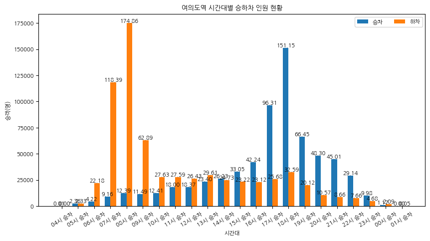

```python
# CSV 파일을 데이터프레임으로 변환
subway_people = pd.read_excel("서울시 지하철 호선별 역별 시간대별 승하차 인원 정보.xlsx")

# '여의도'역만 추출
subway_df = subway_people[subway_people['지하철역'] == '여의도']


# 승차 및 하차 데이터 분리
subway_df_on = [column for column in subway_df.columns if '승차' in column]
up = subway_df[subway_df_on]

subway_df_off = [column for column in subway_df.columns if '하차' in column]
down = subway_df[subway_df_off]

# 데이터 월별 평균 계산
subway_df_on = up.mean()
subway_df_off = down.mean()


plt.rcParams['font.size'] = 8

# 다중 막대그래프 그리기
w = 0.35
nrow = subway_df_on.shape[0] # 행의 갯수
idx = np.arange(nrow) #행의 갯수

fig, ax = plt.subplots(figsize=(10, 5))
ax.set_title('여의도역 시간대별 승하차 인원 현황')
ax.set_xlabel('시간대')
ax.set_ylabel('승객(명)')
bars1 = ax.bar(idx - w/2, subway_df_on.values, width=w, label='승차')
bars2 = ax.bar(idx + w/2, subway_df_off.values, width=w, label='하차')

# 막대 위에 값 표시 (천단위로)
for i in bars1:
    ax.text(i.get_x() + i.get_width() / 2, i.get_height(), f"{i.get_height() / 1000:.2f}", ha='center', va='bottom')

for i in bars2:
    ax.text(i.get_x() + i.get_width() / 2, i.get_height(), f"{i.get_height() / 1000:.2f}", ha='center', va='bottom')

# x축에 인덱스 넣기
ax.set_xticks(idx)
ax.set_xticklabels(subway_df_on.index, rotation=30)
ax.legend(ncol=2)
plt.savefig('sci.png', dpi=300)
plt.show()
```

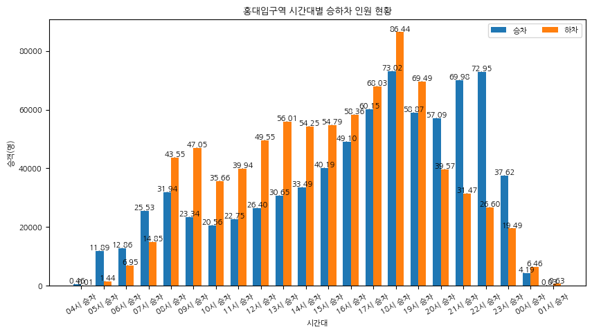

```python
subway_people = pd.read_excel("서울시 지하철 호선별 역별 시간대별 승하차 인원 정보.xlsx")

# '홍대입구'역만 추출
subway_df = subway_people[subway_people['지하철역'] == '홍대입구']
#%%

# 승차 및 하차 데이터 분리
subway_df_on = [column for column in subway_df.columns if '승차' in column]
up = subway_df[subway_df_on]

#%%
subway_df_off = [column for column in subway_df.columns if '하차' in column]
down = subway_df[subway_df_off]
#%%
# 데이터 월별 평균 계산
subway_df_on = up.mean()
subway_df_off = down.mean()

plt.rcParams['font.size'] = 8

# 다중 막대그래프 그리기
w = 0.35
nrow = subway_df_on.shape[0] # 행의 갯수
idx = np.arange(nrow) #행의 갯수

fig, ax = plt.subplots(figsize=(10, 5))
ax.set_title('홍대입구역 시간대별 승하차 인원 현황')
ax.set_xlabel('시간대')
ax.set_ylabel('승객(명)')
bars1 = ax.bar(idx - w/2, subway_df_on.values, width=w, label='승차')
bars2 = ax.bar(idx + w/2, subway_df_off.values, width=w, label='하차')

# 막대 위에 값 표시 (천단위로)
for i in bars1:
    ax.text(i.get_x() + i.get_width() / 2, i.get_height(), f"{i.get_height() / 1000:.2f}", ha='center', va='bottom')

for i in bars2:
    ax.text(i.get_x() + i.get_width() / 2, i.get_height(), f"{i.get_height() / 1000:.2f}", ha='center', va='bottom')

# x축에 인덱스 넣기
ax.set_xticks(idx)
ax.set_xticklabels(subway_df_on.index, rotation=30)
ax.legend(ncol=2)
plt.savefig('hongdae.png', dpi=300)
plt.show()
```

##### 서울교통공사 1-8호선 30분 단위 평균 혼잡도로 30분간 지나는 열차들의 평균 혼잡도

##### (정원대비 승차인원으로, 승차인과 좌석수가 일치할 경우를 혼잡도 34%로 산정) 입니다.

```
        7시00분  7시30분  8시00분  8시30분  9시00분  17시00분  17시30분  18시00분  18시30분  \
출발역상하
여의도상선     NaN    NaN    NaN    NaN    NaN    81.3   102.2   105.7    86.1
여의도하선    52.8   79.2  103.3   76.2   53.0    59.7    51.5    54.3     NaN
홍대입구내선   50.5   72.6  116.1   87.4   65.6     NaN     NaN     NaN     NaN
홍대입구외선    NaN    NaN   50.5    NaN    NaN    60.6    65.6    86.4    90.5

        19시00분  20시30분  21시00분
출발역상하
여의도상선     61.2    51.1    50.6
여의도하선      NaN     NaN     NaN
홍대입구내선     NaN     NaN     NaN
홍대입구외선    57.9    71.3    51.1
```

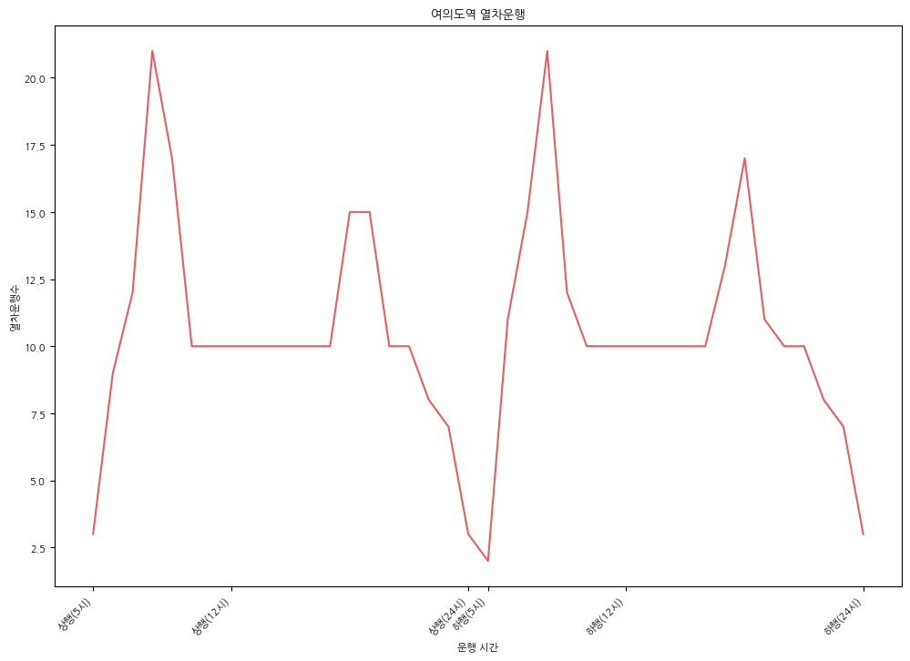

```python
# 조사한 상위역중 2역을 중심으로 혼잡도,
data = pd.read_excel('여의도,홍대입구_시간별_혼잡도.xlsx')
# 평일부분만 추출
weekday_data = data.iloc[[0,1,6,7]]
# 평일에 시간부분만 추출
weekday_data_A = weekday_data.iloc[:,5:][weekday_data.iloc[:, 5:] > 50]
# 시간부분에 결측값이 2개이상인 열은 제외해서 조금더 확인
weekday_data_df = weekday_data_A.dropna(axis=1,thresh=weekday_data_A.shape[0]-2)
weekday_data_df.reset_index(drop=True, inplace=True)
# 출발역상하 = ['여의도상선','여의도하선','홍대입구내선','홍대입구외선']
weekday_data_df.index = ['여의도상선','여의도하선','홍대입구내선','홍대입구외선']
weekday_data_df = weekday_data_df.rename_axis('출발역상하')
print(weekday_data_df)
#%%
all_A = pd.read_excel('평일 여의도역 지하철 운행 정보.xlsx')
all_B = pd.read_excel('평일 홍대입구역 지하철 운행 정보.xlsx')
all_A = all_A.count()
all_B = all_B.count()
all_A = pd.DataFrame(all_A)
all_B = pd.DataFrame(all_B)
all_A_values = all_A[0].to_list()
all_B_values = all_B[0].to_list()
#%% 바그래프
plt.figure(figsize=(12, 8))
plt.plot(all_A.index,all_A_values,color = '#e35f62')
plt.xticks(rotation=45, ha='right')
plt.xlabel('운행 시간')
plt.ylabel('열차운행수')
plt.title('여의도역 열차운행')
plt.xticks(['상행(5시)','상행(12시)','상행(24시)','하행(5시)','하행(12시)','하행(24시)'])
plt.show()
```

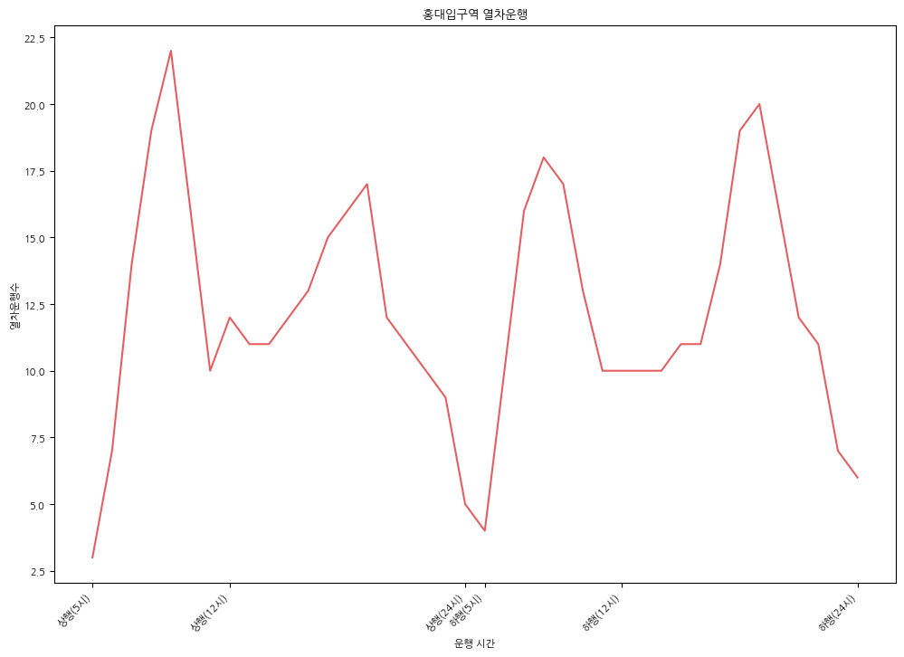

```python
plt.figure(figsize=(12, 8))
plt.plot(all_B.index,all_B_values,color = '#e35f62')
plt.xticks(rotation=45, ha='right')
plt.xlabel('운행 시간')
plt.ylabel('열차운행수')
plt.title('홍대입구역 열차운행')
plt.xticks(['상행(5시)','상행(12시)','상행(24시)','하행(5시)','하행(12시)','하행(24시)'])
plt.show()
```

#### 열차 운행수 기준으로 정제한 다음 바 그래프로 시각화를 해보았습니다.

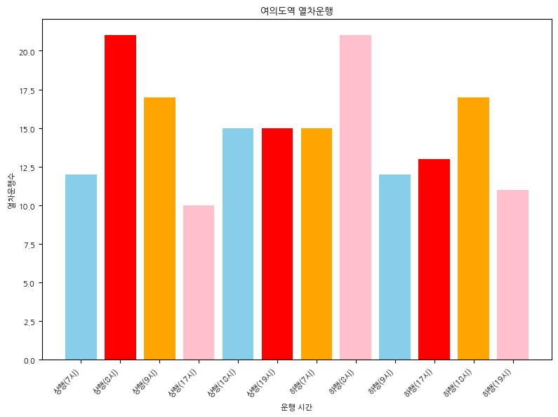

```python
data_A = pd.read_excel('여의도역 7시~9시 배차간격.xlsx')
data_B = pd.read_excel('홍대입구역 7시~9시 배차간격.xlsx')
index_length_A = data_A.count()
index_length_A = pd.DataFrame(index_length_A)
index_length_A.rename(columns={0 : '열차운행수'},inplace=True)
index_length_B = data_B.count()
index_length_B = pd.DataFrame(index_length_B)
index_length_B.rename(columns={0 : '열차운행수'},inplace=True)
b = index_length_A['열차운행수'].to_list()


plt.figure(figsize=(8, 6))
plt.bar(index_length_A.index,b,color = ['skyblue','r','orange','pink'])

# x축 이름 기울기
plt.xticks(rotation=45, ha='right')
plt.xlabel('운행 시간')
plt.ylabel('열차운행수')
plt.title('여의도역 열차운행')

plt.tight_layout()
plt.show()
```

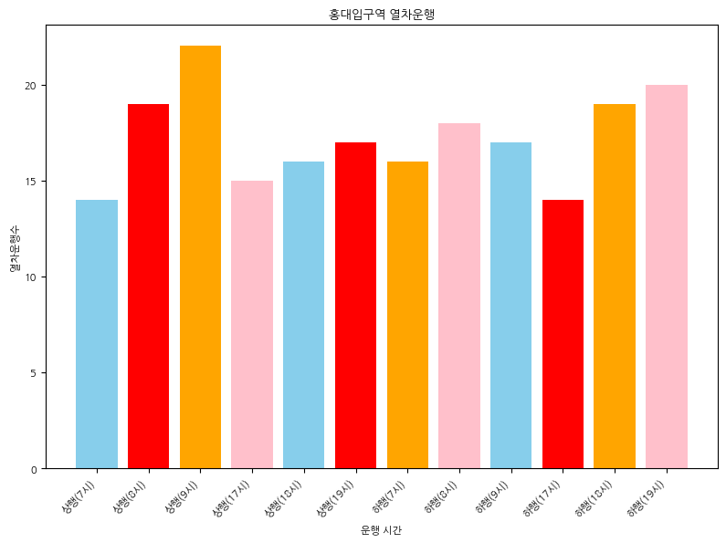

```python
c = index_length_B.index.to_list()
d = index_length_B['열차운행수'].to_list()


plt.figure(figsize=(8, 6))
plt.bar(c,d,color = ['skyblue','r','orange','pink'])

# x축 이름 기울기
plt.xticks(rotation=45, ha='right')
plt.xlabel('운행 시간')
plt.ylabel('열차운행수')
plt.title('홍대입구역 열차운행')

plt.tight_layout()
plt.show()
```

### 다른 시간대에 비해 많은 열차수가 운행을 하지만 그럼에도 혼잡도가 높은것을 알 수 있습니다.

## 문제 해결 :

#### - 가장 많이 탑승하는 시간때인 출퇴근 시간에 더 많은 열차 수를 늘린다.

#### - 더욱 많은 역을 건설하여 사람들을 분산 시킨다.

#### - 향후 정부에서 직장 근처에서 저렴하고 쾌적하게 생활 할 수 있는 주거 모형 개발이 필요 할꺼 같다

### 조사하면서 느낀점 :

#### - 문성현 : 생각보다 많은 인원이 경기도권과 서울에 몰려있고 조금 더 쾌적한 이동수단이 필요한걸 느꼈습니다.

#### - 홍현하 : 데이터 전처리 과정이 중요한거 같다. 조금 더 공부가 필요할꺼같다.

#### - 이의형 : 2호선을 사람들이 많이 이용한다는 것을 느꼈고 조사 외쪽인 느낌도 조금 넣자면 많이 이용하는 역은 밤에도 사람들이 많은 것을 느꼈다.